# Week4-2

Kyu Cho

Tuesday, June 30, 2015

```r
library(rpart)
library(rpart.plot)

setwd("D:/Google Drive/College/4-The Analytics Edge/data4")
Claims = read.csv("ClaimsData.csv")
summary(Claims)
```

```
##       age           alzheimers       arthritis          cancer
##  Min.   : 26.00   Min.   :0.0000   Min.   :0.0000   Min.   :0.00000
##  1st Qu.: 67.00   1st Qu.:0.0000   1st Qu.:0.0000   1st Qu.:0.00000
##  Median : 73.00   Median :0.0000   Median :0.0000   Median :0.00000
##  Mean   : 72.63   Mean   :0.1922   Mean   :0.1543   Mean   :0.06411
##  3rd Qu.: 81.00   3rd Qu.:0.0000   3rd Qu.:0.0000   3rd Qu.:0.00000
##  Max.   :100.00   Max.   :1.0000   Max.   :1.0000   Max.   :1.00000
##       copd          depression        diabetes      heart.failure
##  Min.   :0.0000   Min.   :0.0000   Min.   :0.0000   Min.   :0.0000
##  1st Qu.:0.0000   1st Qu.:0.0000   1st Qu.:0.0000   1st Qu.:0.0000
##  Median :0.0000   Median :0.0000   Median :0.0000   Median :0.0000
##  Mean   :0.1361   Mean   :0.2131   Mean   :0.3805   Mean   :0.2847
##  3rd Qu.:0.0000   3rd Qu.:0.0000   3rd Qu.:1.0000   3rd Qu.:1.0000
##  Max.   :1.0000   Max.   :1.0000   Max.   :1.0000   Max.   :1.0000
##       ihd             kidney        osteoporosis       stroke
##  Min.   :0.0000   Min.   :0.0000   Min.   :0.000   Min.   :0.00000
##  1st Qu.:0.0000   1st Qu.:0.0000   1st Qu.:0.000   1st Qu.:0.00000
##  Median :0.0000   Median :0.0000   Median :0.000   Median :0.00000
##  Mean   :0.4201   Mean   :0.1612   Mean   :0.174   Mean   :0.04479
##  3rd Qu.:1.0000   3rd Qu.:0.0000   3rd Qu.:0.000   3rd Qu.:0.00000
##  Max.   :1.0000   Max.   :1.0000   Max.   :1.000   Max.   :1.00000
##  reimbursement2008   bucket2008    reimbursement2009   bucket2009
##  Min.   :     0    Min.   :1.000   Min.   :     0    Min.   :1.000
##  1st Qu.:     0    1st Qu.:1.000   1st Qu.:   130    1st Qu.:1.000
##  Median :   950    Median :1.000   Median :  1540    Median :1.000
##  Mean   :  4005    Mean   :1.437   Mean   :  4277    Mean   :1.522
##  3rd Qu.:  3110    3rd Qu.:2.000   3rd Qu.:  4220    3rd Qu.:2.000
##  Max.   :221640    Max.   :5.000   Max.   :189930    Max.   :5.000
```

```r
str(Claims)
```

```
## 'data.frame':    458005 obs. of  16 variables:
##  $ age              : int  85 59 67 52 67 68 75 70 67 67 ...
##  $ alzheimers       : int  0 0 0 0 0 0 0 0 0 0 ...
##  $ arthritis        : int  0 0 0 0 0 0 0 0 0 0 ...
##  $ cancer           : int  0 0 0 0 0 0 0 0 0 0 ...
##  $ copd             : int  0 0 0 0 0 0 0 0 0 0 ...
##  $ depression       : int  0 0 0 0 0 0 0 0 0 0 ...
##  $ diabetes         : int  0 0 0 0 0 0 0 0 0 0 ...
##  $ heart.failure    : int  0 0 0 0 0 0 0 0 0 0 ...
##  $ ihd              : int  0 0 0 0 0 0 0 0 0 0 ...
##  $ kidney           : int  0 0 0 0 0 0 0 0 0 0 ...
##  $ osteoporosis     : int  0 0 0 0 0 0 0 0 0 0 ...
##  $ stroke           : int  0 0 0 0 0 0 0 0 0 0 ...
##  $ reimbursement2008: int  0 0 0 0 0 0 0 0 0 0 ...
##  $ bucket2008       : int  1 1 1 1 1 1 1 1 1 1 ...
##  $ reimbursement2009: int  0 0 0 0 0 0 0 0 0 0 ...
##  $ bucket2009       : int  1 1 1 1 1 1 1 1 1 1 ...
```

These cost buckets are defined using the thresholds determined by D2Hawkeye. So the first cost bucket contains patients with costs less than $3,000, the second cost bucket contains patients with costs between $3,000 and $8,000, and so on.

We can verify that the number of patients in each cost bucket has the same structure as what we saw for D2Hawkeye by computing the percentage of patients in each cost bucket.

```r
table(Claims$bucket2009)/nrow(Claims)
```

```
##
##           1           2           3           4           5
## 0.671267781 0.190170413 0.089466272 0.043324855 0.005770679
```

The first cost bucket has almost 70% of the patients.  
The second cost bucket has about 20% of the patients.  
And the remaining 10% are split between the final three cost buckets.  
So the vast majority of patients in this data set have low cost.

Our goal will be to predict the cost bucket the patient fell into in 2009 using a CART model.

# Spliting the data

```r
library(caTools)
set.seed(88)
spl = sample.split(Claims$bucket2009, SplitRatio = 0.6)
ClaimsTrain = subset(Claims, spl==TRUE)
ClaimsTest = subset(Claims, spl==FALSE)

# Average age of patients in the training set
mean(ClaimsTrain$age)
```

```
## [1] 72.63773
```

```r
# Proportion of people in the training set (ClaimsTrain) had at least one diagnosis code for diabetes.
sum(ClaimsTrain$diabetes)/nrow(ClaimsTrain)
```

```
## [1] 0.3808983
```

# Build smart baseline

The baseline method would predict that the cost bucket for a patient in 2009 will be the same as it was in 2008.

```r
# First = output data, Second = prediction
table(ClaimsTest$bucket2009, ClaimsTest$bucket2008)
```

```
##
##          1      2      3      4      5
##   1 110138   7787   3427   1452    174
##   2  16000  10721   4629   2931    559
##   3   7006   4629   2774   1621    360
##   4   2688   1943   1415   1539    352
##   5    293    191    160    309    104
```

The accuracy is the sum of the diagonal, the observations that were classified correctly, divided by the total number of observations in our test set.

```r
# Accuracy
(110138 + 10721 + 2774 + 1539 + 104)/nrow(ClaimsTest)
```

```
## [1] 0.6838135
```

```r
# Penalty error
# Left = actual outcomes,  Top = predicted outcomes
PenaltyMatrix = matrix(c(0,1,2,3,4,2,0,1,2,3,4,2,0,1,2,6,4,2,0,1,8,6,4,2,0), byrow=TRUE, nrow=5)
PenaltyMatrix
```

```
##      [,1] [,2] [,3] [,4] [,5]
## [1,]    0    1    2    3    4
## [2,]    2    0    1    2    3
## [3,]    4    2    0    1    2
## [4,]    6    4    2    0    1
## [5,]    8    6    4    2    0
```

So now to compute the penalty error of the baseline method, we need to multiply our classification matrix by the penalty matrix.  
Use as.matrix to convert it to a matrix so that we can multiply it by our penalty matrix.

```r
# Penalty Error of Baseline Method
as.matrix(table(ClaimsTest$bucket2009, ClaimsTest$bucket2008))*PenaltyMatrix
```

```
##
##         1     2     3     4     5
##   1     0  7787  6854  4356   696
##   2 32000     0  4629  5862  1677
##   3 28024  9258     0  1621   720
##   4 16128  7772  2830     0   352
##   5  2344  1146   640   618     0
```

```r
sum(as.matrix(table(ClaimsTest$bucket2009, ClaimsTest$bucket2008))*PenaltyMatrix)/nrow(ClaimsTest)
```

```
## [1] 0.7386055
```

So the penalty error for the baseline method is 0.74.

We can impove the CART model that has an accuracy higher than 68% and a panalty error lower than .74

# Modify the baseline

Let’s use the baseline method of predicting the most frequent outcome for all observations.  
This new baseline method would predict cost bucket 1 for everyone.  
What would the accuracy of this baseline method be on the test set?

```r
# To compute the accuracy, you can create a table of the variable ClaimsTest$bucket2009:
table(ClaimsTest$bucket2009)
```

```
##
##      1      2      3      4      5
## 122978  34840  16390   7937   1057
```

```r
# According to the table output, this baseline method would get 122978 observations correct, and all other observations wrong. So the accuracy of this baseline method is
122978/nrow(ClaimsTest)
```

```
## [1] 0.67127
```

```r
# For the penalty error, since this baseline method predicts 1 for all observations, it would have a penalty error of:
(0*122978 + 2*34840 + 4*16390 + 6*7937 + 8*1057)/nrow(ClaimsTest)
```

```
## [1] 1.044301
```

# Build cart model

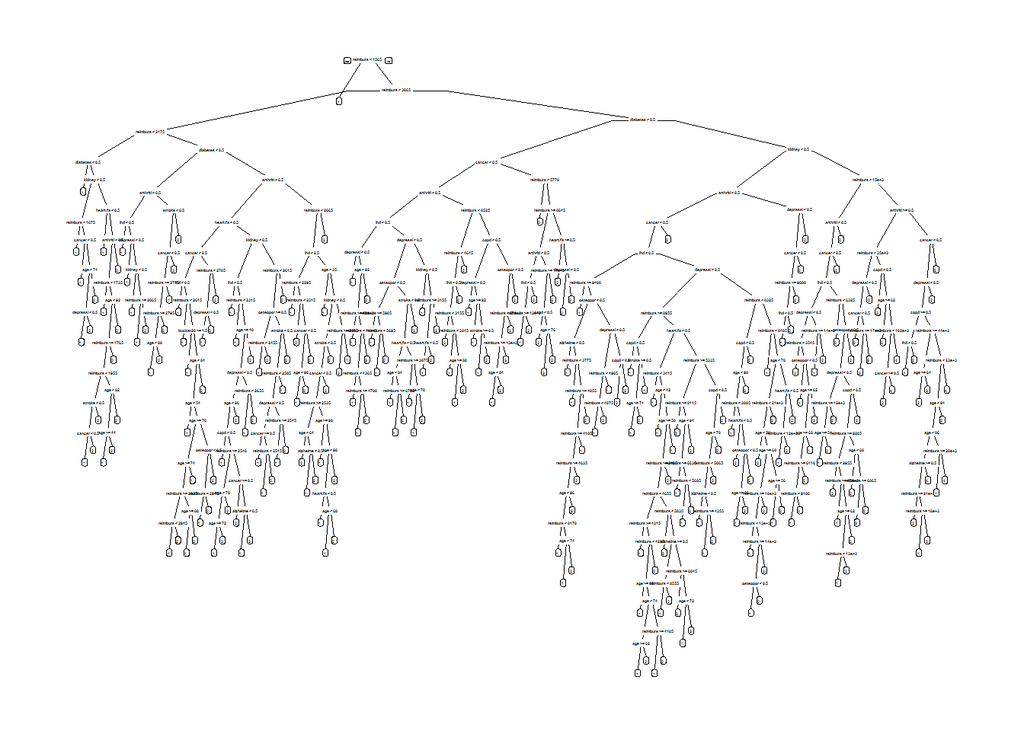

```r
# CART model
ClaimsTree = rpart(bucket2009~age+alzheimers+arthritis+cancer+copd+depression+diabetes+heart.failure+ihd+kidney+osteoporosis+stroke+bucket2008+reimbursement2008, data=ClaimsTrain, method="class", cp=0.00005)
prp(ClaimsTree)
```

```r
# Make predictions
PredictTest = predict(ClaimsTree, newdata = ClaimsTest, type = "class")
table(ClaimsTest$bucket2009, PredictTest)
```

```
##    PredictTest
##          1      2      3      4      5
##   1 114141   8610    124    103      0
##   2  18409  16102    187    142      0
##   3   8027   8146    118     99      0
##   4   3099   4584     53    201      0
##   5    351    657      4     45      0
```

```r
# Accuracy
(114141 + 16102 + 118 + 201 + 0)/nrow(ClaimsTest)
```

```
## [1] 0.7126669
```

```r
# Penalty error
as.matrix(table(ClaimsTest$bucket2009, PredictTest))*PenaltyMatrix
```

```
##    PredictTest
##         1     2     3     4     5
##   1     0  8610   248   309     0
##   2 36818     0   187   284     0
##   3 32108 16292     0    99     0
##   4 18594 18336   106     0     0
##   5  2808  3942    16    90     0
```

```r
sum(as.matrix(table(ClaimsTest$bucket2009, PredictTest))*PenaltyMatrix)/nrow(ClaimsTest)
```

```
## [1] 0.7578902
```

```r
# New CART model with loss matrix
ClaimsTree = rpart(bucket2009~age+alzheimers+arthritis+cancer+copd+depression+diabetes+heart.failure+ihd+kidney+osteoporosis+stroke+bucket2008+reimbursement2008, data=ClaimsTrain, method="class", cp=0.00005, parms=list(loss=PenaltyMatrix))

# Redo predictions and penalty error
PredictTest = predict(ClaimsTree, newdata = ClaimsTest, type = "class")
table(ClaimsTest$bucket2009, PredictTest)
```

```
##    PredictTest
##         1     2     3     4     5
##   1 94310 25295  3087   286     0
##   2  7176 18942  8079   643     0
##   3  3590  7706  4692   401     1
##   4  1304  3193  2803   636     1
##   5   135   356   408   156     2
```

```r
# Accuracy
(94310 + 18942 + 4692 + 636 + 2)/nrow(ClaimsTest)
```

```
## [1] 0.6472746
```

```r
sum(as.matrix(table(ClaimsTest$bucket2009, PredictTest))*PenaltyMatrix)/nrow(ClaimsTest)
```

```
## [1] 0.6418161
```

So the penalty error of our new model is 0.642. Our accuracy is now lower than the baseline method, but our penalty error is also much lower. Note that we have significantly fewer independent variables than D2Hawkeye had. If we had the hundreds of codes and risk factors available to D2Hawkeye, we would hopefully do even better.